# The Guide to Build the Best Possible Fantasy Basketball Lineup

#### Nihal Garisa, Neha Konduru

## Introduction

**What is fantasy basketball and what is the aim of our project?**

Fantasy basketball is a game where participants create virtual teams composed of real NBA players. These teams compete based on the statistical performance of the players in actual games. Each player accumulates fantasy points through various actions such as scoring, assists, rebounds, steals, and blocks. The objective is to select a lineup of players who will collectively score the most points within a week. Predicting the best possible fantasy basketball lineup involves analyzing a vast amount of data from past and current NBA games. The challenge lies in processing and interpreting information, such as player statistics, to make accurate predictions about future player performances.

**Why is this important?**

For fantasy basketball enthusiasts like ourselves, having a data-driven approach to selecting players can significantly enhance their chances of winning. It transforms the game from a casual hobby into a strategic and analytical competition. Fantasy basketball is a rapidly growing industry with millions of participants worldwide. Successful fantasy players can win substantial prizes like money, and platforms hosting these games benefit from higher user engagement and satisfaction. Therefore, developing accurate prediction models can have significant benefits for people and businesses involved in fantasy sports.

Beyond fantasy sports, the methodologies and insights gained from this project can contribute to the broader field of sports analytics. Teams, coaches, and analysts can use similar techniques to improve real-world strategies and performance evaluations. This project aims to leverage advanced analytical techniques to create a model that can provide fantasy basketball players with a competitive edge, contributing to both personal and professional growth in the field of data science.

Over this tutorial, we will be going through the data science lifecycle as follows:

1. Data Collection
2. Data Cleaning
3. Exploratory Analysis and Data Visualization
4. Model: Analysis, Hypothesis Testing, and ML
5. Interpretation: Insight & Policy Decision

## Part 1: Data Collection

To develop this project, we will be using the Python language and Jupyter Lab, an interactive development environment. If you are new to Jupyter Lab, you can learn more about it [here](https://docs.jupyter.org/en/latest/). In this section, we will collect all relevant NBA player data from a trusted source using Python. We will start by importing several relevant Python libraries to use throughout this tutorial.

```python
import requests
import seaborn as sns
import numpy as np
import pandas as pd
pd.set_option('display.max_columns', None)
import time
from bs4 import BeautifulSoup
import matplotlib.pyplot as plt
import statsmodels.api as sm
import statsmodels.formula.api as smf
from sklearn.model_selection import train_test_split
from sklearn.linear_model import LinearRegression
from sklearn.metrics import mean_squared_error, r2_score
from sklearn.model_selection import GridSearchCV
from sklearn.ensemble import RandomForestClassifier
from sklearn.metrics import accuracy_score
import statsmodels.api as sm
import statsmodels.formula.api as smf
from sklearn.tree import DecisionTreeRegressor
from sklearn.ensemble import RandomForestRegressor
from sklearn.tree import plot_tree
```

One of the main libraries we will use in this project is [Pandas](https://pandas.pydata.org/docs/). It is an open-source tool built on Python that makes data manipulation easy and flexible. Another library that boosts efficiency is [NumPy](https://numpy.org/devdocs/user/). It allows easy computation for large datasets and provides another way to store and handle information.

Now, we will look for a dataset we can use for our topic. Since our topic is based on [ESPN’s default fantasy basketball scoring system](https://www.espn.com/fantasy/basketball/story/_/id/30296896/espn-fantasy-default-points-league-scoring-explained), we looked for the official NBA player data from a website called [Basketball Reference](https://www.basketball-reference.com/), which is one of the official websites that track NBA data. We verified the legitimacy of the website as it is a popular and widely respected source for accurate basketball statistics, detailed player profiles, and historical data. Additionally, the website is often used by sports analysts, journalists, and fans for reliable information and in-depth analysis.

Specifically, we gathered HTML files containing player performance data from the 2012-13 to the [2023-24 NBA season](https://www.basketball-reference.com/leagues/NBA_2024_totals.html) using HTTP GET requests to the relevant HTML files from Basketball Reference. Then, we parse the saved HTML files for each season to extract the player statistics table, convert each table into a pandas dataframe, and store all these dataframes in a list. Each dataframe in the list corresponds to the player statistics for a specific NBA season.

```python
years = list(range(2013,2025))
player_totals_url = "https://www.basketball-reference.com/leagues/NBA_{}_totals.html"
for yr in years:
    url = player_totals_url.format(yr)
    data = requests.get(url)
    with open("totals/{}.html".format(yr), "w+") as f:
        f.write(data.text)
```

```python
dfs = []
for yr in years:
    with open("totals/{}.html".format(yr)) as f:
        page = f.read()
    soup = BeautifulSoup(page, "html.parser")
    soup.find('tr', class_="full_table").decompose()
    stats_table = soup.find(id="totals_stats")
    players = pd.read_html(str(stats_table))[0]
    dfs.append(players)
```

**Data Explanation**

To explain fantasy basketball’s default points-league scoring system, we referred to the [article](https://www.espn.com/fantasy/basketball/story/_/id/30296896/espn-fantasy-default-points-league-scoring-explained) mentioned previously from ESPN’s website. Specifically, the website contains a detailed breakdown of the default point scoring system. For a more detailed breakdown of what each column variable in our dataframes mean, we referred to the glossary available above Basketball Reference’s player statistics tables.

ESPN default scoring system for fantasy basketball:

- Point = 1
- 3P = 1
- FGA = -1
- FG = 2
- FTA = -1
- FT = 1
- TRB = 1
- AST = 2
- STL = 4
- BLK = 4
- TOV = -2

Glossary of basketball stats terms:

- Rk = Rank
- Pos = Position
- Age = Player's age on February 1 of the season
- Tm = Team
- G = Games
- GS = Games Started
- MP = Minutes Played
- FG = Field Goals
- FGA = Field Goal Attempts
- FG% = Field Goal Percentage
- 3P = 3-Point Field Goals
- 3PA = 3-Point Field Goal Attempts
- 3P% = 3-Point Field Goal Percentage
- 2P = 2-Point Field Goals
- 2PA = 2-Point Field Goal Attempts
- 2P% = 2-Point Field Goal Percentage
- eFG% = Effective Field Goal Percentage
- FT = Free Throws
- FTA = Free Throw Attempts
- FT% = Free Throw Percentage
- ORB = Offensive Rebounds
- DRB = Defensive Rebounds
- TRB = Total Rebounds
- AST = Assists
- STL = Steals
- BLK = Blocks
- TOV = Turnovers
- PF = Personal Fouls
- PTS = Points

```python
dfs[0].head()
```

|  | Rk | Player | Pos | Age | Tm | G | GS | MP | FG | FGA | FG% | 3P | 3PA | 3P% | 2P | 2PA | 2P% | eFG% | FT | FTA | FT% | ORB | DRB | TRB | AST | STL | BLK | TOV | PF | … |
| --- | --- | --- | --- | --- | --- | --- | --- | --- | --- | --- | --- | --- | --- | --- | --- | --- | --- | --- | --- | --- | --- | --- | --- | --- | --- | --- | --- | --- | --- | --- |
| 0 | 2 | Jeff Adrien | PF | 26 | CHA | 52 | 5 | 713 | 72 | 168 | .429 | 0 | 2 | .000 | 72 | 166 | .434 | .429 | 65 | 100 | .650 | 68 | 128 | 196 | 36 | 18 | 27 | 32 | 80 | … |
| 1 | 3 | Arron Afflalo | SF | 27 | ORL | 64 | 64 | 2307 | 397 | 905 | .439 | 72 | 240 | .300 | 325 | 665 | .489 | .478 | 191 | 223 | .857 | 29 | 210 | 239 | 206 | 40 | 11 | 138 | 137 | … |
| 2 | 4 | Josh Akognon | PG | 26 | DAL | 3 | 0 | 9 | 2 | 4 | .500 | 1 | 2 | .500 | 1 | 2 | .500 | .625 | 0 | 0 | NaN | 0 | 1 | 1 | 1 | 0 | 0 | 0 | 3 | … |
| 3 | 5 | Cole Aldrich | C | 24 | TOT | 45 | 0 | 388 | 44 | 80 | .550 | 0 | 0 | NaN | 44 | 80 | .550 | .550 | 12 | 20 | .600 | 30 | 90 | 120 | 9 | 5 | 23 | 23 | 60 | … |
| 4 | 5 | Cole Aldrich | C | 24 | HOU | 30 | 0 | 213 | 23 | 43 | .535 | 0 | 0 | NaN | 23 | 43 | .535 | .535 | 4 | 9 | .444 | 12 | 45 | 57 | 6 | 3 | 9 | 14 | 41 | … |

## Part 2: Data Cleaning

Now that we have collected all of our data, we need to clean and format it properly.

**Formatting**

First, we process the dataframes for each season by removing certain columns that are not relevant to fantasy scoring calculations. The columns we targeted for removal include the shooting percentages (e.g., FG%, 3P%), effective field goal percentage (eFG%), offensive and defensive rebounds (ORB, DRB), personal fouls (PF), and rank (Rk).

```python
columns_to_drop = ['FG%', '3P%', '2P%', 'eFG%', 'ORB', 'DRB', 'PF', 'FT%', 'Rk']

for df in dfs:
    columns_to_drop_existing = [col for col in columns_to_drop if col in df.columns]
    df.drop(columns=columns_to_drop_existing, inplace=True)
```

```python
dfs[1]
```

|  | Player | Pos | Age | Tm | G | GS | MP | FG | FGA | 3P | 3PA | 2P | 2PA | FT | FTA | TRB | AST | STL | BLK | TOV | PTS |
| --- | --- | --- | --- | --- | --- | --- | --- | --- | --- | --- | --- | --- | --- | --- | --- | --- | --- | --- | --- | --- | --- |
| 0 | Quincy Acy | SF | 23 | TOR | 7 | 0 | 61 | 6 | 14 | 2 | 5 | 4 | 9 | 5 | 8 | 15 | 4 | 4 | 3 | 2 | 19 |
| 1 | Quincy Acy | SF | 23 | SAC | 56 | 0 | 786 | 60 | 127 | 2 | 10 | 58 | 117 | 30 | 45 | 201 | 24 | 19 | 23 | 28 | 152 |
| 2 | Steven Adams | C | 20 | OKC | 81 | 20 | 1197 | 93 | 185 | 0 | 0 | 93 | 185 | 79 | 136 | 332 | 43 | 40 | 57 | 71 | 265 |
| 3 | Jeff Adrien | PF | 27 | TOT | 53 | 12 | 961 | 143 | 275 | 0 | 0 | 143 | 275 | 76 | 119 | 306 | 38 | 24 | 36 | 39 | 362 |
| 4 | Jeff Adrien | PF | 27 | CHA | 25 | 0 | 256 | 22 | 40 | 0 | 0 | 22 | 40 | 13 | 25 | 88 | 7 | 7 | 15 | 8 | 57 |
| ... | ... | ... | ... | ... | ... | ... | ... | ... | ... | ... | ... | ... | ... | ... | ... | ... | ... | ... | ... | ... | ... |
| 629 | Nick Young | SG | 28 | LAL | 64 | 9 | 1810 | 387 | 889 | 135 | 350 | 252 | 539 | 235 | 285 | 166 | 95 | 46 | 12 | 95 | 1144 |
| 630 | Thaddeus Young | PF | 25 | PHI | 79 | 78 | 2718 | 582 | 1283 | 90 | 292 | 492 | 991 | 163 | 229 | 476 | 182 | 167 | 36 | 165 | 1417 |
| 631 | Player | Pos | Age | Tm | G | GS | MP | FG | FGA | 3P | 3PA | 2P | 2PA | FT | FTA | TRB | AST | STL | BLK | TOV | PTS |
| 632 | Cody Zeller | C | 21 | CHA | 82 | 3 | 1416 | 172 | 404 | 0 | 1 | 172 | 403 | 146 | 200 | 353 | 92 | 40 | 41 | 87 | 490 |
| 633 | Tyler Zeller | C | 24 | CLE | 70 | 9 | 1049 | 156 | 290 | 0 | 1 | 156 | 289 | 87 | 121 | 282 | 36 | 18 | 38 | 60 | 399 |

634 rows × 21 columns

Next, to make the table more readable, we remove the rows from each dataframe where the 'Player' column contains the string 'Player', to remove misplaced header rows we received from the HTML files.

```python
for i in range(len(dfs)):
    dfs[i] = dfs[i].drop(dfs[i][dfs[i]['Player'] == 'Player'].index)
```

```python
dfs[1]
```

|  | Player | Pos | Age | Tm | G | GS | MP | FG | FGA | 3P | 3PA | 2P | 2PA | FT | FTA | TRB | AST | STL | BLK | TOV | PTS |
| --- | --- | --- | --- | --- | --- | --- | --- | --- | --- | --- | --- | --- | --- | --- | --- | --- | --- | --- | --- | --- | --- |
| 0 | Quincy Acy | SF | 23 | TOR | 7 | 0 | 61 | 6 | 14 | 2 | 5 | 4 | 9 | 5 | 8 | 15 | 4 | 4 | 3 | 2 | 19 |
| 1 | Quincy Acy | SF | 23 | SAC | 56 | 0 | 786 | 60 | 127 | 2 | 10 | 58 | 117 | 30 | 45 | 201 | 24 | 19 | 23 | 28 | 152 |
| 2 | Steven Adams | C | 20 | OKC | 81 | 20 | 1197 | 93 | 185 | 0 | 0 | 93 | 185 | 79 | 136 | 332 | 43 | 40 | 57 | 71 | 265 |
| 3 | Jeff Adrien | PF | 27 | TOT | 53 | 12 | 961 | 143 | 275 | 0 | 0 | 143 | 275 | 76 | 119 | 306 | 38 | 24 | 36 | 39 | 362 |
| 4 | Jeff Adrien | PF | 27 | CHA | 25 | 0 | 256 | 22 | 40 | 0 | 0 | 22 | 40 | 13 | 25 | 88 | 7 | 7 | 15 | 8 | 57 |
| ... | ... | ... | ... | ... | ... | ... | ... | ... | ... | ... | ... | ... | ... | ... | ... | ... | ... | ... | ... | ... | ... |
| 628 | Tony Wroten | PG | 20 | PHI | 72 | 16 | 1765 | 345 | 808 | 40 | 188 | 305 | 620 | 209 | 326 | 228 | 217 | 78 | 16 | 204 | 939 |
| 629 | Nick Young | SG | 28 | LAL | 64 | 9 | 1810 | 387 | 889 | 135 | 350 | 252 | 539 | 235 | 285 | 166 | 95 | 46 | 12 | 95 | 1144 |
| 630 | Thaddeus Young | PF | 25 | PHI | 79 | 78 | 2718 | 582 | 1283 | 90 | 292 | 492 | 991 | 163 | 229 | 476 | 182 | 167 | 36 | 165 | 1417 |
| 632 | Cody Zeller | C | 21 | CHA | 82 | 3 | 1416 | 172 | 404 | 0 | 1 | 172 | 403 | 146 | 200 | 353 | 92 | 40 | 41 | 87 | 490 |
| 633 | Tyler Zeller | C | 24 | CLE | 70 | 9 | 1049 | 156 | 290 | 0 | 1 | 156 | 289 | 87 | 121 | 282 | 36 | 18 | 38 | 60 | 399 |

610 rows × 21 columns

It is important to note that the default data type for columns in Pandas dataframes is strings. Thus, we convert all columns supposed to be containing integer data in each dataframe from the default string type to integer type. The selected columns include various statistical categories like points scored, rebounds, assists, and other performance metrics. This conversion enhances computational efficiency for subsequent data analysis tasks.

```python
for i in range(len(dfs)):
    columns_to_convert = ['Age', 'G', 'GS', 'MP', 'FG', 'FGA', '3P', '3PA', '2P', '2PA', 'FT', 'FTA', 'TRB', 'AST', 'STL', 'BLK', 'TOV', 'PTS']
    dfs[i][columns_to_convert] = dfs[i][columns_to_convert].astype(int)
```

```python
dfs[1]
```

|  | Player | Pos | Age | Tm | G | GS | MP | FG | FGA | 3P | 3PA | 2P | 2PA | FT | FTA | TRB | AST | STL | BLK | TOV | PTS |
| --- | --- | --- | --- | --- | --- | --- | --- | --- | --- | --- | --- | --- | --- | --- | --- | --- | --- | --- | --- | --- | --- |
| 0 | Quincy Acy | SF | 23 | TOR | 7 | 0 | 61 | 6 | 14 | 2 | 5 | 4 | 9 | 5 | 8 | 15 | 4 | 4 | 3 | 2 | 19 |
| 1 | Quincy Acy | SF | 23 | SAC | 56 | 0 | 786 | 60 | 127 | 2 | 10 | 58 | 117 | 30 | 45 | 201 | 24 | 19 | 23 | 28 | 152 |
| 2 | Steven Adams | C | 20 | OKC | 81 | 20 | 1197 | 93 | 185 | 0 | 0 | 93 | 185 | 79 | 136 | 332 | 43 | 40 | 57 | 71 | 265 |
| 3 | Jeff Adrien | PF | 27 | TOT | 53 | 12 | 961 | 143 | 275 | 0 | 0 | 143 | 275 | 76 | 119 | 306 | 38 | 24 | 36 | 39 | 362 |
| 4 | Jeff Adrien | PF | 27 | CHA | 25 | 0 | 256 | 22 | 40 | 0 | 0 | 22 | 40 | 13 | 25 | 88 | 7 | 7 | 15 | 8 | 57 |
| ... | ... | ... | ... | ... | ... | ... | ... | ... | ... | ... | ... | ... | ... | ... | ... | ... | ... | ... | ... | ... | ... |
| 628 | Tony Wroten | PG | 20 | PHI | 72 | 16 | 1765 | 345 | 808 | 40 | 188 | 305 | 620 | 209 | 326 | 228 | 217 | 78 | 16 | 204 | 939 |
| 629 | Nick Young | SG | 28 | LAL | 64 | 9 | 1810 | 387 | 889 | 135 | 350 | 252 | 539 | 235 | 285 | 166 | 95 | 46 | 12 | 95 | 1144 |
| 630 | Thaddeus Young | PF | 25 | PHI | 79 | 78 | 2718 | 582 | 1283 | 90 | 292 | 492 | 991 | 163 | 229 | 476 | 182 | 167 | 36 | 165 | 1417 |
| 632 | Cody Zeller | C | 21 | CHA | 82 | 3 | 1416 | 172 | 404 | 0 | 1 | 172 | 403 | 146 | 200 | 353 | 92 | 40 | 41 | 87 | 490 |
| 633 | Tyler Zeller | C | 24 | CLE | 70 | 9 | 1049 | 156 | 290 | 0 | 1 | 156 | 289 | 87 | 121 | 282 | 36 | 18 | 38 | 60 | 399 |

610 rows × 21 columns

Some players play on multiple teams in one season and their data is displayed in separate rows per team they played in. Thus, we aggregate player statistics for those who played for multiple teams in a single season, consolidating their data into a single row. This ensures that each player's data is represented equally on the dataframes.

```python
def concat_teams(teams):
    return ','.join(sorted(set(teams)))

agg_funcs = {
    'Age': 'first',
    'Pos': 'first',
    'G': 'sum',
    'GS': 'sum',
    'MP': 'sum',
    'FG': 'sum',
    'FGA': 'sum',
    '3P': 'sum',
    '3PA': 'sum',
    '2P': 'sum',
    '2PA': 'sum',
    'FT': 'sum',
    'FTA': 'sum',
    'TRB': 'sum',
    'AST': 'sum',
    'STL': 'sum',
    'BLK': 'sum',
    'TOV': 'sum',
    'PTS': 'sum',
    'Tm': concat_teams
}

# List to hold the aggregated dataframes
df_list = []

for df in dfs:
    # Filter out rows where the team is 'TOT'
    df_filtered = df[df['Tm'] != 'TOT']
    # Group by player and apply the aggregation functions
    grouped_df = df_filtered.groupby('Player').agg(agg_funcs).reset_index()
    df_list.append(grouped_df)
```

**Dealing with Missing Data**

For each dataframe, we add back the percentage columns we previously dropped and make a case where if a player does not attempt the relevant shot variable (which causes the case where we must divide by 0), we change the default NaN (missing) values to the integer 0. Note that percentages are not part of fantasy point calculations, but will serve as an important data point to make insights later on.

```python
def add_percentage_columns(df):
    df['FG%'] = df.apply(lambda row: row['FG'] / row['FGA'] if row['FGA'] > 0 else 0, axis=1)
    df['3P%'] = df.apply(lambda row: row['3P'] / row['3PA'] if row['3PA'] > 0 else 0, axis=1)
    df['2P%'] = df.apply(lambda row: row['2P'] / row['2PA'] if row['2PA'] > 0 else 0, axis=1)
    df['eFG%'] = df.apply(lambda row: (row['FG'] + 0.5 * row['3P']) / row['FGA'] if row['FGA'] > 0 else 0, axis=1)
    df['FT%'] = df.apply(lambda row: row['FT'] / row['FTA'] if row['FTA'] > 0 else 0, axis=1)
    return df
df_list = [add_percentage_columns(df) for df in df_list]
```

**Filtering**

Next, we filter out players in each dataframe who do not have the top 400 minutes played in the season, because players who do not have as many minutes played can skew the data, which can cause outliers. Thus, it is important to include players who have played for a consistent amount of time across the season.

```python
def filter_top_400_by_minutes(df):
    return df.sort_values(by='MP', ascending=False).head(400)

filtered_df_list = [filter_top_400_by_minutes(df) for df in df_list]

filtered_df_list[1].head()
```

|  | Player | Age | Pos | G | GS | MP | FG | FGA | 3P | 3PA | 2P | 2PA | FT | FTA | TRB | AST | STL | BLK | TOV | PTS | Tm | FG% | 3P% | 2P% | eFG% | FT% |
| --- | --- | --- | --- | --- | --- | --- | --- | --- | --- | --- | --- | --- | --- | --- | --- | --- | --- | --- | --- | --- | --- | --- | --- | --- | --- | --- |
| 265 | Kevin Durant | 25 | SF | 81 | 81 | 3122 | 849 | 1688 | 192 | 491 | 657 | 1197 | 703 | 805 | 598 | 445 | 103 | 59 | 285 | 2593 | OKC | 0.502962 | 0.391039 | 0.548872 | 0.559834 | 0.873292 |
| 335 | Monta Ellis | 28 | SG | 82 | 82 | 3023 | 576 | 1278 | 69 | 209 | 507 | 1069 | 339 | 430 | 295 | 471 | 141 | 23 | 264 | 1560 | DAL | 0.450704 | 0.330144 | 0.474275 | 0.477700 | 0.788372 |
| 111 | DeMar DeRozan | 24 | SG | 79 | 79 | 3017 | 604 | 1407 | 64 | 210 | 540 | 1197 | 519 | 630 | 343 | 313 | 86 | 28 | 176 | 1791 | TOR | 0.429282 | 0.304762 | 0.451128 | 0.452026 | 0.823810 |
| 65 | Carmelo Anthony | 29 | PF | 77 | 77 | 2982 | 743 | 1643 | 167 | 415 | 576 | 1228 | 459 | 541 | 622 | 242 | 95 | 51 | 198 | 2112 | NYK | 0.452222 | 0.402410 | 0.469055 | 0.503043 | 0.848429 |
| 237 | John Wall | 23 | PG | 82 | 82 | 2980 | 579 | 1337 | 108 | 308 | 471 | 1029 | 317 | 394 | 333 | 721 | 149 | 40 | 295 | 1583 | WAS | 0.433059 | 0.350649 | 0.457726 | 0.473448 | 0.804569 |

```python
filtered_df_list[2].head()
```

|  | Player | Age | Pos | G | GS | MP | FG | FGA | 3P | 3PA | 2P | 2PA | FT | FTA | TRB | AST | STL | BLK | TOV | PTS | Tm | FG% | 3P% | 2P% | eFG% | FT% |
| --- | --- | --- | --- | --- | --- | --- | --- | --- | --- | --- | --- | --- | --- | --- | --- | --- | --- | --- | --- | --- | --- | --- | --- | --- | --- | --- |
| 200 | James Harden | 25 | SG | 81 | 81 | 2981 | 647 | 1470 | 208 | 555 | 439 | 915 | 715 | 824 | 459 | 565 | 154 | 60 | 321 | 2217 | HOU | 0.440136 | 0.374775 | 0.479781 | 0.510884 | 0.867718 |
| 27 | Andrew Wiggins | 19 | SF | 82 | 82 | 2969 | 497 | 1137 | 39 | 126 | 458 | 1011 | 354 | 466 | 374 | 170 | 86 | 50 | 177 | 1387 | MIN | 0.437115 | 0.309524 | 0.453017 | 0.454266 | 0.759657 |
| 459 | Trevor Ariza | 29 | SF | 82 | 82 | 2930 | 366 | 910 | 194 | 555 | 172 | 355 | 122 | 143 | 459 | 209 | 152 | 17 | 141 | 1048 | HOU | 0.402198 | 0.349550 | 0.484507 | 0.508791 | 0.853147 |
| 91 | Damian Lillard | 24 | PG | 82 | 82 | 2925 | 590 | 1360 | 196 | 572 | 394 | 788 | 344 | 398 | 378 | 507 | 97 | 21 | 222 | 1720 | POR | 0.433824 | 0.342657 | 0.500000 | 0.505882 | 0.864322 |
| 79 | Chris Paul | 29 | PG | 82 | 82 | 2857 | 568 | 1170 | 139 | 349 | 429 | 821 | 289 | 321 | 376 | 838 | 156 | 15 | 190 | 1564 | LAC | 0.485470 | 0.398281 | 0.522533 | 0.544872 | 0.900312 |

## Part 3: Exploratory Analysis & Data Visualization

In this phase of the data science life cycle, we will graph the data to enhance our understanding and perform statistical analyses to obtain mathematical evidence for any identified trends.

Using the ESPN default scoring key, mentioned in the previous section, we added the total points accumulated for each category and put this data in a new column called ‘FP_TOTAL’. For clarity, we also included the total points accumulated for each category in separate columns to visualize before totaling the final fantasy score in ‘FP_TOTAL’ for each player.

```python
def add_fantasy_columns(df):
    df['FP_PTS'] = df.apply(lambda row: row['PTS'], axis=1)
    df['FP_3P'] = df.apply(lambda row: row['3P'], axis=1)
    df['FP_FGA'] = df.apply(lambda row: row['FGA'] * -1, axis=1)
    df['FP_FG'] = df.apply(lambda row: row['FG'] * 2, axis=1)
    df['FP_FTA'] = df.apply(lambda row: row['FTA']* -1, axis=1)
    df['FP_FT'] = df.apply(lambda row: row['FT'], axis=1)
    df['FP_TRB'] = df.apply(lambda row: row['TRB'], axis=1)
    df['FP_AST'] = df.apply(lambda row: row['AST'] * 2, axis=1)
    df['FP_STL'] = df.apply(lambda row: row['STL'] * 4, axis=1)
    df['FP_BLK'] = df.apply(lambda row: row['BLK'] * 4, axis=1)
    df['FP_TOV'] = df.apply(lambda row: row['TOV'] * -2, axis=1)
    return df
filtered_df_list = [add_fantasy_columns(df) for df in filtered_df_list]
```

```python
filtered_df_list[4].head()
```

|  | Player | Age | Pos | G | GS | MP | FG | FGA | 3P | 3PA | 2P | 2PA | FT | FTA | TRB | AST | STL | BLK | TOV | PTS | Tm | FG% | 3P% | 2P% | eFG% | FT% | FP_PTS | FP_3P | FP_FGA | … |
| --- | --- | --- | --- | --- | --- | --- | --- | --- | --- | --- | --- | --- | --- | --- | --- | --- | --- | --- | --- | --- | --- | --- | --- | --- | --- | --- | --- | --- | --- | --- |
| 24 | Andrew Wiggins | 21 | SF | 82 | 82 | 3048 | 709 | 1570 | 103 | 289 | 606 | 1281 | 412 | 542 | 328 | 189 | 82 | 30 | 187 | 1933 | MIN | 0.451592 | 0.356401 | 0.473068 | 0.484395 | 0.760148 | 1933 | 103 | -1570 | … |
| 257 | Karl-Anthony Towns | 21 | C | 82 | 82 | 3030 | 802 | 1480 | 101 | 275 | 701 | 1205 | 356 | 428 | 1007 | 220 | 56 | 103 | 212 | 2061 | MIN | 0.541892 | 0.367273 | 0.581743 | 0.576014 | 0.831776 | 2061 | 101 | -1480 | … |
| 193 | James Harden | 27 | PG | 81 | 81 | 2947 | 674 | 1533 | 262 | 756 | 412 | 777 | 746 | 881 | 659 | 907 | 121 | 38 | 464 | 2356 | HOU | 0.439661 | 0.346561 | 0.530245 | 0.525114 | 0.846765 | 2356 | 262 | -1533 | … |
| 159 | Giannis Antetokounmpo | 22 | SF | 80 | 80 | 2845 | 656 | 1259 | 49 | 180 | 607 | 1079 | 471 | 612 | 700 | 434 | 131 | 151 | 234 | 1832 | MIL | 0.521048 | 0.272222 | 0.562558 | 0.540508 | 0.769608 | 1832 | 49 | -1259 | … |
| 230 | John Wall | 26 | PG | 78 | 78 | 2836 | 647 | 1435 | 89 | 272 | 558 | 1163 | 422 | 527 | 326 | 831 | 157 | 49 | 322 | 1805 | WAS | 0.450871 | 0.327206 | 0.479794 | 0.481882 | 0.800759 | 1805 | 89 | -1435 | … |

```python
def get_total_fp(df):
    df['FP_Total'] = df.apply(lambda row: row['FP_PTS'] + row['FP_3P'] + row['FP_FGA'] + row['FP_FG'] + row['FP_FTA'] + row['FP_FT'] + row['FP_TRB'] + row['FP_AST'] + row['FP_STL'] + row['FP_BLK'] + row['FP_TOV'], axis=1)
    return df
filtered_df_list = [get_total_fp(df) for df in filtered_df_list]
```

```python
filtered_df_list[5].head()
```

|  | Player | Age | Pos | G | GS | MP | FG | FGA | 3P | 3PA | 2P | 2PA | FT | FTA | TRB | AST | STL | BLK | TOV | PTS | Tm | FG% | 3P% | 2P% | eFG% | FT% | FP_PTS | FP_3P | FP_FGA | … |
| --- | --- | --- | --- | --- | --- | --- | --- | --- | --- | --- | --- | --- | --- | --- | --- | --- | --- | --- | --- | --- | --- | --- | --- | --- | --- | --- | --- | --- | --- | --- |
| 324 | LeBron James | 33 | PF | 82 | 82 | 3026 | 857 | 1580 | 149 | 406 | 708 | 1174 | 388 | 531 | 709 | 747 | 116 | 71 | 347 | 2251 | CLE | 0.542405 | 0.366995 | 0.603066 | 0.589557 | 0.730697 | 2251 | 149 | -1580 | … |
| 303 | Khris Middleton | 26 | SF | 82 | 82 | 2982 | 593 | 1272 | 146 | 407 | 447 | 865 | 320 | 362 | 429 | 328 | 119 | 21 | 191 | 1652 | MIL | 0.466195 | 0.358722 | 0.516763 | 0.523585 | 0.883978 | 1652 | 146 | -1272 | … |
| 25 | Andrew Wiggins | 22 | SF | 82 | 82 | 2979 | 569 | 1300 | 112 | 338 | 457 | 962 | 202 | 314 | 358 | 160 | 91 | 51 | 138 | 1452 | MIN | 0.437692 | 0.331361 | 0.475052 | 0.480769 | 0.643312 | 1452 | 112 | -1300 | … |
| 47 | Bradley Beal | 24 | SG | 82 | 82 | 2977 | 683 | 1484 | 199 | 530 | 484 | 954 | 292 | 369 | 363 | 373 | 96 | 36 | 214 | 1857 | WAS | 0.460243 | 0.375472 | 0.507338 | 0.527291 | 0.791328 | 1857 | 199 | -1484 | … |
| 278 | Jrue Holiday | 27 | SG | 81 | 81 | 2927 | 615 | 1244 | 120 | 356 | 495 | 888 | 187 | 238 | 365 | 486 | 123 | 64 | 213 | 1537 | NOP | 0.494373 | 0.337079 | 0.557432 | 0.542605 | 0.785714 | 1537 | 120 | -1244 | … |

In the rest of this section, we will leverage visualization! Throughout this tutorial, we will mainly use the [Matplotlib](https://matplotlib.org/stable/tutorials/index) and [Seaborn](https://seaborn.pydata.org/tutorial.html) libraries. If you are new to these libraries, feel free to learn more about them through the provided links, as they are incredibly valuable tools for data visualization.

First, we visualize the overall fantasy data across a different number of seasons using bar graphs.

We start by graphing average fantasy points per player position across all seasons. To clarify the abbreviations for the positions:

- PG = Point Guard
- C = Center
- PF = Power Forward
- SG = Shooting Guard
- SF = Small Forward

Why this matters? According to ESPN, the default setting roster for a fantasy basketball system includes one point guard (PG), one shooting guard (SG), one small forward (SF), one power forward (PF), one center (C), one SG/PG, one forward SF/PF, three of any position, and three backup spots of any position.

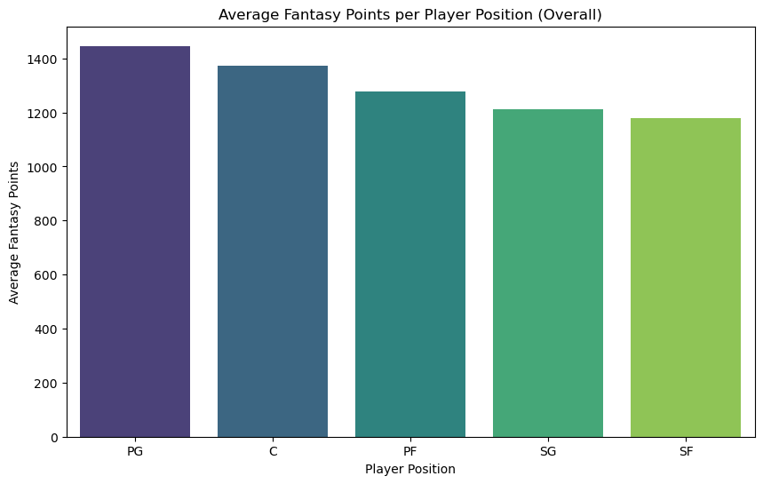

```python
combined_df = pd.concat(filtered_df_list, ignore_index=True)

average_fp_per_pos = combined_df.groupby('Pos')['FP_Total'].mean().reset_index()

average_fp_per_pos = average_fp_per_pos.sort_values('FP_Total', ascending=False)

plt.figure(figsize=(10, 6))
sns.barplot(x='Pos', y='FP_Total', data=average_fp_per_pos, palette='viridis')
plt.title('Average Fantasy Points per Player Position (Overall)')
plt.xlabel('Player Position')
plt.ylabel('Average Fantasy Points')
plt.show()
```

As you can see, the average fantasy points for point guards (PG) across all seasons were the highest among all the other positions, while small forwards (SF) had the least average fantasy points. We think this is because in the earlier seasons, point guards had the ball the most, which caused them to generate the most statistics.

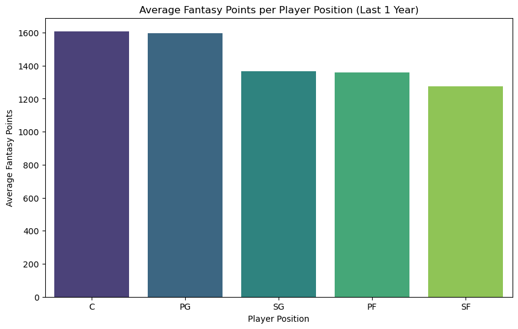

```python
last_5_dfs = filtered_df_list[-1:]
combined_df = pd.concat(last_5_dfs, ignore_index=True)
average_fp_per_pos = combined_df.groupby('Pos')['FP_Total'].mean().reset_index()
average_fp_per_pos = average_fp_per_pos.sort_values('FP_Total', ascending=False)
plt.figure(figsize=(10, 6))
sns.barplot(x='Pos', y='FP_Total', data=average_fp_per_pos, palette='viridis')
plt.title('Average Fantasy Points per Player Position (Last 1 Year)')
plt.xlabel('Player Position')
plt.ylabel('Average Fantasy Points')
plt.show()
```

Here, we see that the average fantasy points for centers (C) from last season were the highest among all the other positions, while small forwards (SF) still had the least average fantasy points. We think this is because gameplans today have evolved to have playmaking and scoring through centers. This evolution took place as centers started developing a similar skill set as point guards, but centers are taller than point guards, which gives them a further advantage. In the earlier seasons, centers were not as skilled as point guards in scoring and playmaking, so they were kept from generating as many fantasy points, which explains the outcomes of both of our plots.

These trends are further analyzed in the website below: https://sportsanalytics.studentorg.berkeley.edu/articles/point-centers.html

Now, we visualize the relationship between percentage data and fantasy points using scatter plots.

Here, we try to determine if there is a relationship between field goal percentage and fantasy points for each player.

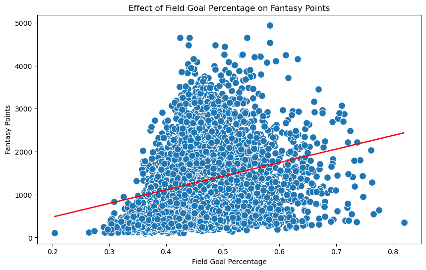

```
                            OLS Regression Results
==============================================================================
Dep. Variable:               FP_Total   R-squared:                       0.072
Model:                            OLS   Adj. R-squared:                  0.072
Method:                 Least Squares   F-statistic:                     372.8
Date:                Sat, 18 May 2024   Prob (F-statistic):           4.62e-80
Time:                        23:35:36   Log-Likelihood:                -38828.
No. Observations:                4800   AIC:                         7.766e+04
Df Residuals:                    4798   BIC:                         7.767e+04
Df Model:                           1
Covariance Type:            nonrobust
==============================================================================
                 coef    std err          t      P>|t|      [0.025      0.975]
------------------------------------------------------------------------------
const       -154.7550     75.960     -2.037      0.042    -303.672      -5.838
FG%         3162.7308    163.799     19.309      0.000    2841.610    3483.852
==============================================================================
Omnibus:                      447.779   Durbin-Watson:                   0.336
Prob(Omnibus):                  0.000   Jarque-Bera (JB):              583.826
Skew:                           0.805   Prob(JB):                    1.67e-127
Kurtosis:                       3.572   Cond. No.                         17.4
==============================================================================

Notes:
[1] Standard Errors assume that the covariance matrix of the errors is correctly specified.
```

```python
combined_df = pd.concat(filtered_df_list, ignore_index=True)
X = combined_df['FG%']
y = combined_df['FP_Total']
X = sm.add_constant(X)
model = sm.OLS(y, X).fit()
intercept, slope = model.params
plt.figure(figsize=(10, 6))
sns.scatterplot(x='FG%', y='FP_Total', data=combined_df, s=100)
plt.plot(combined_df['FG%'], slope * combined_df['FG%'] + intercept, color='red')
plt.title('Effect of Field Goal Percentage on Fantasy Points')
plt.xlabel('Field Goal Percentage')
plt.ylabel('Fantasy Points')
plt.show()
print(model.summary())
```

Next, we try to determine if there is a relationship between three-point percentage and fantasy points for each player.

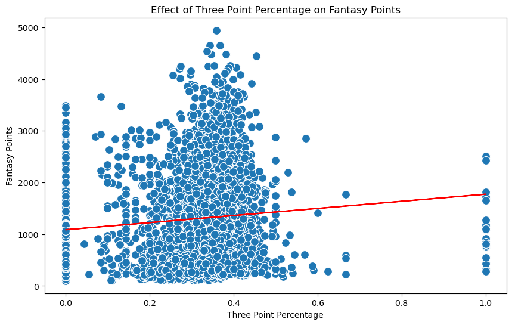

```
                            OLS Regression Results
==============================================================================
Dep. Variable:               FP_Total   R-squared:                       0.012
Model:                            OLS   Adj. R-squared:                  0.012
Method:                 Least Squares   F-statistic:                     60.00
Date:                Sat, 18 May 2024   Prob (F-statistic):           1.15e-14
Time:                        23:35:37   Log-Likelihood:                -38978.
No. Observations:                4800   AIC:                         7.796e+04
Df Residuals:                    4798   BIC:                         7.797e+04
Df Model:                           1
Covariance Type:            nonrobust
==============================================================================
                 coef    std err          t      P>|t|      [0.025      0.975]
------------------------------------------------------------------------------
const       1086.4137     29.422     36.926      0.000    1028.734    1144.094
3P%          687.2690     88.725      7.746      0.000     513.327     861.211
==============================================================================
Omnibus:                      501.808   Durbin-Watson:                   0.388
Prob(Omnibus):                  0.000   Jarque-Bera (JB):              670.437
Skew:                           0.876   Prob(JB):                    2.61e-146
Kurtosis:                       3.535   Cond. No.                         8.26
==============================================================================

Notes:
[1] Standard Errors assume that the covariance matrix of the errors is correctly specified.
```

```python
X = combined_df['3P%']
y = combined_df['FP_Total']
X = sm.add_constant(X)
model = sm.OLS(y, X).fit()
intercept, slope = model.params
plt.figure(figsize=(10, 6))
sns.scatterplot(x='3P%', y='FP_Total', data=combined_df, s=100)
plt.plot(combined_df['3P%'], slope * combined_df['3P%'] + intercept, color='red')
plt.title('Effect of Three Point Percentage on Fantasy Points')
plt.xlabel('Three Point Percentage')
plt.ylabel('Fantasy Points')
plt.show()
print(model.summary())
```

Here, we see that there is not a strong correlation between three-point percentage and fantasy points for each player as the linear regression line looks fairly horizontal. This goes to show that having a high three-point percentage does not necessarily indicate that a player will receive a high number of fantasy points. Therefore, this shows that the player’s overall ability to score is more important than scoring three-pointers.

Next, we try to determine if there is a relationship between effective three-point percentage and fantasy points for each player. Effective field goal percentage takes into account both two-pointer and three-pointer shots, where three-pointers provide additional weight: EFFECTIVE FIELD GOAL PERCENTAGE FORMULA: (FG + 0.5 * 3P) / FGA

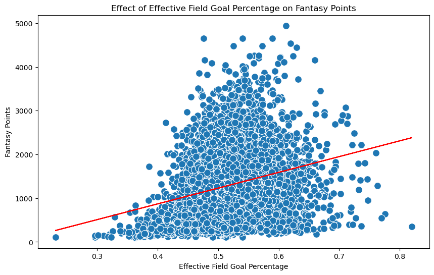

```
                            OLS Regression Results
==============================================================================
Dep. Variable:               FP_Total   R-squared:                       0.068
Model:                            OLS   Adj. R-squared:                  0.068
Method:                 Least Squares   F-statistic:                     351.0
Date:                Sat, 18 May 2024   Prob (F-statistic):           1.20e-75
Time:                        23:35:38   Log-Likelihood:                -38838.
No. Observations:                4800   AIC:                         7.768e+04
Df Residuals:                    4798   BIC:                         7.769e+04
Df Model:                           1
Covariance Type:            nonrobust
==============================================================================
                 coef    std err          t      P>|t|      [0.025      0.975]
------------------------------------------------------------------------------
const       -570.9918    100.267     -5.695      0.000    -767.561    -374.423
eFG%        3601.2584    192.215     18.736      0.000    3224.430    3978.087
==============================================================================
Omnibus:                      490.114   Durbin-Watson:                   0.383
Prob(Omnibus):                  0.000   Jarque-Bera (JB):              653.471
Skew:                           0.853   Prob(JB):                    1.26e-142
Kurtosis:                       3.599   Cond. No.                         21.4
==============================================================================

Notes:
[1] Standard Errors assume that the covariance matrix of the errors is correctly specified.
```

```python
combined_df = pd.concat(filtered_df_list, ignore_index=True)
X = combined_df['eFG%']
y = combined_df['FP_Total']
X = sm.add_constant(X)
model = sm.OLS(y, X).fit()
intercept, slope = model.params
plt.figure(figsize=(10, 6))
sns.scatterplot(x='eFG%', y='FP_Total', data=combined_df, s=100)
plt.plot(combined_df['eFG%'], slope * combined_df['eFG%'] + intercept, color='red')
plt.title('Effect of Effective Field Goal Percentage on Fantasy Points')
plt.xlabel('Effective Field Goal Percentage')
plt.ylabel('Fantasy Points')
plt.show()
print(model.summary())
```

Lastly, we try to determine if there is a relationship between free throw percentage and fantasy points for each player.

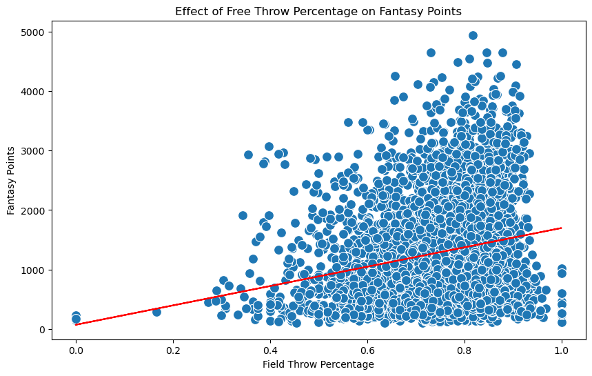

```
                            OLS Regression Results
==============================================================================
Dep. Variable:               FP_Total   R-squared:                       0.047
Model:                            OLS   Adj. R-squared:                  0.047
Method:                 Least Squares   F-statistic:                     235.1
Date:                Sat, 18 May 2024   Prob (F-statistic):           7.53e-52
Time:                        23:35:39   Log-Likelihood:                -38893.
No. Observations:                4800   AIC:                         7.779e+04
Df Residuals:                    4798   BIC:                         7.780e+04
Df Model:                           1
Covariance Type:            nonrobust
==============================================================================
                 coef    std err          t      P>|t|      [0.025      0.975]
------------------------------------------------------------------------------
const         71.8411     80.621      0.891      0.373     -86.212     229.894
FT%         1626.2832    106.056     15.334      0.000    1418.365    1834.201
==============================================================================
Omnibus:                      473.797   Durbin-Watson:                   0.450
Prob(Omnibus):                  0.000   Jarque-Bera (JB):              625.994
Skew:                           0.835   Prob(JB):                    1.17e-136
Kurtosis:                       3.582   Cond. No.                         14.4
==============================================================================

Notes:
[1] Standard Errors assume that the covariance matrix of the errors is correctly specified.
```

```python
combined_df = pd.concat(filtered_df_list, ignore_index=True)
X = combined_df['FT%']
y = combined_df['FP_Total']
X = sm.add_constant(X)
model = sm.OLS(y, X).fit()
intercept, slope = model.params
plt.figure(figsize=(10, 6))
sns.scatterplot(x='FT%', y='FP_Total', data=combined_df, s=100)
plt.plot(combined_df['FT%'], slope * combined_df['FT%'] + intercept, color='red')
plt.title('Effect of Free Throw Percentage on Fantasy Points')
plt.xlabel('Field Throw Percentage')
plt.ylabel('Fantasy Points')
plt.show()
print(model.summary())
```

Now, we visualize the relationship between age and average fantasy points across all seasons using a bar graph.

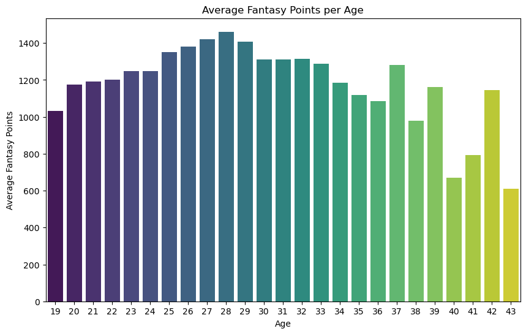

```python
combined_df = pd.concat(filtered_df_list, ignore_index=True)
average_fp_per_age = combined_df.groupby('Age')['FP_Total'].mean().reset_index()
average_fp_per_age = average_fp_per_age.sort_values('Age')

plt.figure(figsize=(10, 6))
sns.barplot(x='Age', y='FP_Total', data=average_fp_per_age, palette='viridis')
plt.title('Average Fantasy Points per Age')
plt.xlabel('Age')
plt.ylabel('Average Fantasy Points')
plt.show()
```

From this graph, we can see that players in their high 20s and early 30s generally have the highest number of fantasy points, while players in their late 30s and 40s generally have the lowest number of fantasy points.

Next, we visualize the relationship between a player who switched teams between seasons and average fantasy points using a bar graph.

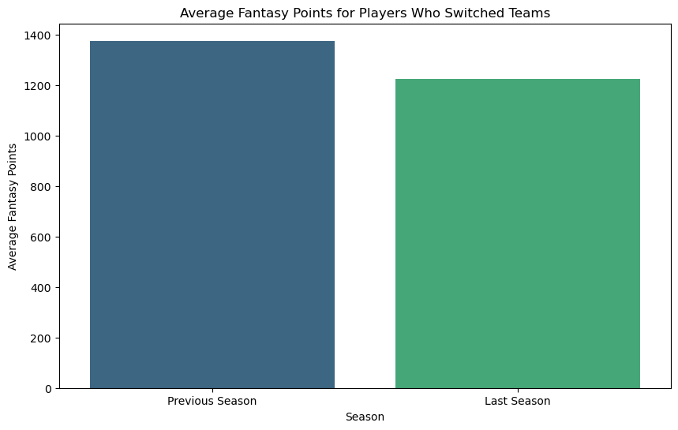

```python
last_season_df = filtered_df_list[-1]
second_last_season_df = filtered_df_list[-2]

merged_df = pd.merge(last_season_df, second_last_season_df, on='Player', suffixes=('_last', '_prev'))

merged_df['Team_Switch'] = merged_df['Tm_last'] != merged_df['Tm_prev']

switched_teams_df = merged_df[merged_df['Team_Switch']]

average_fp_last_season = switched_teams_df['FP_Total_last'].mean()
average_fp_prev_season = switched_teams_df['FP_Total_prev'].mean()

average_fp_diff = average_fp_last_season - average_fp_prev_season

plot_data = pd.DataFrame({
    'Season': ['Previous Season', 'Last Season'],
    'Average_FP': [average_fp_prev_season, average_fp_last_season]
})

plt.figure(figsize=(10, 6))
sns.barplot(x='Season', y='Average_FP', data=plot_data, palette='viridis')
plt.title('Average Fantasy Points for Players Who Switched Teams')
plt.xlabel('Season')
plt.ylabel('Average Fantasy Points')
plt.show()
```

From this graph, we can see that players who switch teams between seasons generally have fewer average fantasy points in their current season. We think this is because players are getting used to adjusting to their new team for the current season, which may hinder their performance.

Now, we visualize the distribution of scoring metric weightages in total fantasy points using pie charts.

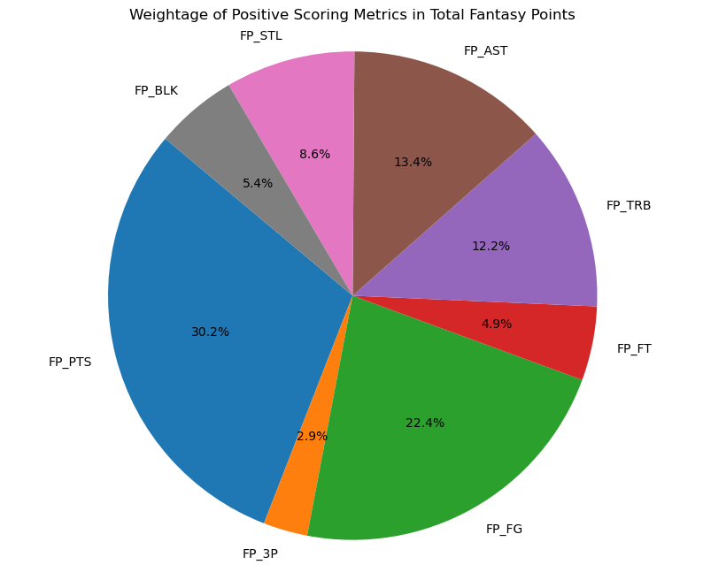

```python
scoring_metrics = ['FP_PTS', 'FP_3P', 'FP_FG', 'FP_FT', 'FP_TRB', 'FP_AST', 'FP_STL', 'FP_BLK']
combined_df = pd.concat(filtered_df_list, ignore_index=True)

scoring_sums = combined_df[scoring_metrics].sum()

scoring_percentage = (scoring_sums / scoring_sums.sum()) * 100

plt.figure(figsize=(10, 8))
plt.pie(scoring_percentage, labels=scoring_percentage.index, autopct='%1.1f%%', startangle=140)
plt.title('Weightage of Positive Scoring Metrics in Total Fantasy Points')
plt.axis('equal')
plt.show()
```

This pie chart shows the distribution of fantasy scoring metric weightage where players can gain points (which is what we mean by positive) to make up the average percentage of a player's gained fantasy points.

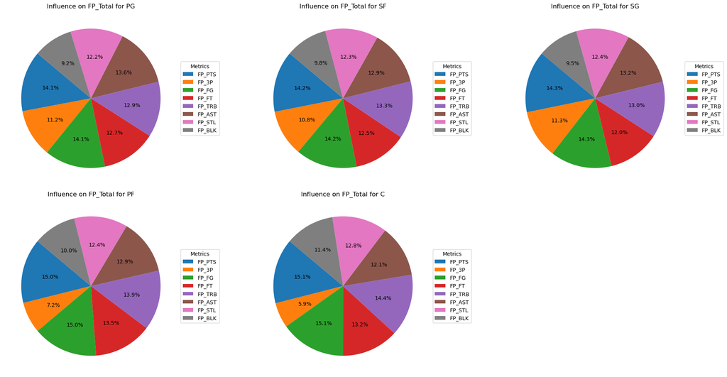

```python
scoring_metrics = ['FP_PTS', 'FP_3P', 'FP_FG', 'FP_FT', 'FP_TRB', 'FP_AST', 'FP_STL', 'FP_BLK']
combined_df = pd.concat(filtered_df_list, ignore_index=True)

positions = combined_df['Pos'].unique()

fig, axes = plt.subplots(2, len(positions) // 2 + len(positions) % 2, figsize=(20, 10), subplot_kw=dict(aspect="equal"))
axes = axes.flatten()

for i, pos in enumerate(positions):
    pos_df = combined_df[combined_df['Pos'] == pos]
    correlations = pos_df[scoring_metrics + ['FP_Total']].corr()['FP_Total'].drop('FP_Total')
    absolute_correlations = correlations.abs()
    wedges, texts, autotexts = axes[i].pie(absolute_correlations, autopct='%1.1f%%', startangle=140)
    axes[i].set_title(f'Influence on FP_Total for {pos}')
    axes[i].legend(wedges, absolute_correlations.index, title="Metrics", loc="center left", bbox_to_anchor=(1, 0, 0.5, 1))

for j in range(i + 1, len(axes)):
    fig.delaxes(axes[j])

plt.tight_layout()
plt.show()
```

The above pie charts show the distribution of default fantasy scoring metrics that have positive weightage that make up each player position’s total fantasy points. Each pie chart has relatively similar distributions.

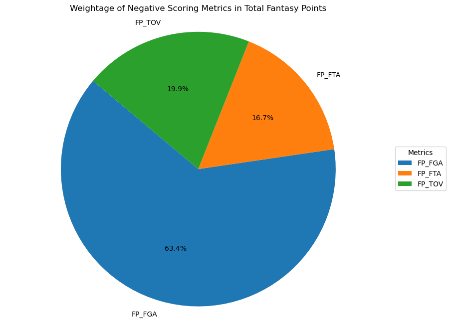

```python
combined_df = pd.concat(filtered_df_list, ignore_index=True)

negative_metrics = ['FP_FGA', 'FP_FTA', 'FP_TOV']

average_losses = combined_df[negative_metrics].mean().abs()

plt.figure(figsize=(10, 8))
wedges, texts, autotexts = plt.pie(average_losses, labels=average_losses.index, autopct='%1.1f%%', startangle=140)
plt.title('Weightage of Negative Scoring Metrics in Total Fantasy Points')
plt.axis('equal')
plt.legend(wedges, average_losses.index, title="Metrics", loc="center left", bbox_to_anchor=(1, 0, 0.5, 1))
plt.show()
```

This pie chart shows the distribution of fantasy scoring metric weightage where players can lose points (which is what we mean by negative) to make up the average percentage of a player's lost fantasy points.

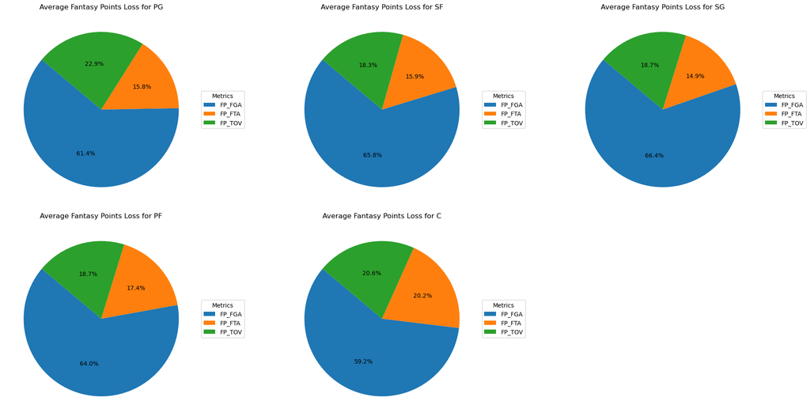

```python
combined_df = pd.concat(filtered_df_list, ignore_index=True)
negative_metrics = ['FP_FGA', 'FP_FTA', 'FP_TOV']
positions = combined_df['Pos'].unique()
fig, axes = plt.subplots(2, len(positions) // 2 + len(positions) % 2, figsize=(20, 10), subplot_kw=dict(aspect="equal"))
axes = axes.flatten()

for i, pos in enumerate(positions):
    pos_df = combined_df[combined_df['Pos'] == pos]
    average_losses = pos_df[negative_metrics].mean().abs()

    wedges, texts, autotexts = axes[i].pie(average_losses, autopct='%1.1f%%', startangle=140)
    axes[i].set_title(f'Average Fantasy Points Loss for {pos}')

    axes[i].legend(wedges, average_losses.index, title="Metrics", loc="center left", bbox_to_anchor=(1, 0, 0.5, 1))

for j in range(i + 1, len(axes)):
    fig.delaxes(axes[j])

plt.tight_layout()
plt.show()
```

The following pie charts show the distribution of default fantasy scoring metrics that have negative weightage that make up each player position’s total fantasy points. Here we can see that centers lose more fantasy points from free throw attempts, since they gain more negative weightage for free throw attempts. Point Guards lose more points from turnovers, since gain more negative weightage for turnovers.

## Part 4: Model: Analysis, Hypothesis Testing, and ML

Hypothesis Test regarding the relationship between Minutes and Games Played

We believe that volume is a large aspect of fantasy points scoring, so minutes and games played can be important factors

Here are our null and alternate hypotheses:

H0: There is no relationship between minutes and games played on fantasy point scoring.

H1: There is a relationship minutes and games played on fantasy point scoring

Running a least squares regression to examine the effects of multiple variables on fantasy basketball scoring

```python
model = smf.ols(formula='FP_Total ~ Age + G + Q("3P%") + GS + Q("eFG%") + Q("FG%") + Q("FT%") + Q("2P%")', data=combined_df).fit()
print(model.summary())
```

```
                            OLS Regression Results
==============================================================================
Dep. Variable:               FP_Total   R-squared:                       0.755
Model:                            OLS   Adj. R-squared:                  0.755
Method:                 Least Squares   F-statistic:                     1848.
Date:                Sat, 18 May 2024   Prob (F-statistic):               0.00
Time:                        23:35:47   Log-Likelihood:                -35630.
No. Observations:                4800   AIC:                         7.128e+04
Df Residuals:                    4791   BIC:                         7.134e+04
Df Model:                           8
Covariance Type:            nonrobust
==============================================================================
                 coef    std err          t      P>|t|      [0.025      0.975]
------------------------------------------------------------------------------
Intercept  -1717.6257     76.216    -22.536      0.000   -1867.044   -1568.207
Age            2.0903      1.396      1.497      0.134      -0.647       4.827
G             15.1789      0.410     37.040      0.000      14.375      15.982
Q("3P%")     619.8662     58.410     10.612      0.000     505.355     734.377
GS            17.3570      0.248     69.936      0.000      16.870      17.844
Q("eFG%")  -1888.2648    226.474     -8.338      0.000   -2332.257   -1444.273
Q("FG%")    3000.0200    203.162     14.767      0.000    2601.730    3398.310
Q("FT%")     925.5394     61.534     15.041      0.000     804.904    1046.175
Q("2P%")     494.2475    158.791      3.113      0.002     182.944     805.551
==============================================================================
Omnibus:                      616.065   Durbin-Watson:                   1.751
Prob(Omnibus):                  0.000   Jarque-Bera (JB):             1598.945
Skew:                           0.719   Prob(JB):                         0.00
Kurtosis:                       5.435   Cond. No.                     3.57e+03
==============================================================================

Notes:
[1] Standard Errors assume that the covariance matrix of the errors is correctly specified.
[2] The condition number is large, 3.57e+03. This might indicate that there are
strong multicollinearity or other numerical problems.
```

```python
features = ['Age', 'G', 'GS', 'MP', '3P%', 'FT%', 'FG%','2P%', 'eFG%']
target = 'FP_Total'
X = combined_df[features]
y = combined_df[target]
X_train, X_test, y_train, y_test = train_test_split(X, y, test_size=0.05)
model = LinearRegression()
model.fit(X_train, y_train)
y_pred = model.predict(X_test)
mse = mean_squared_error(y_test, y_pred)
print(f"Mean Squared Error: {mse}")
print("Coefficients:", model.coef_)
print("Intercept:", model.intercept_)
```

```
Mean Squared Error: 69486.39354592712
Coefficients: [ 1.96775973e+00 -9.92737027e+00  5.12621897e-01  1.18749422e+00
  2.50653080e+02  3.46327930e+02  2.93248928e+03  4.91634053e+02
 -1.61604972e+03]
Intercept: -955.7387567713192
```

```
Final theta: [1295.30949413    5.42380823  -21.4595378   181.03334471  562.84756762
   28.98779362   51.41053839  148.42640373   35.58089283  -52.91286839]
```

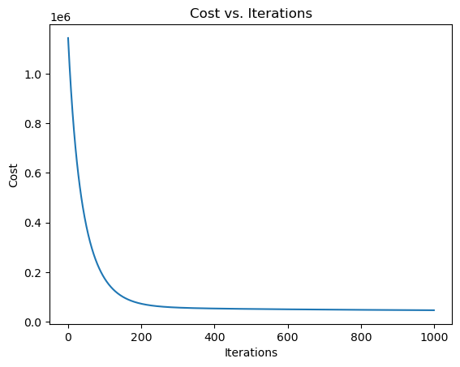

```python
X = combined_df[['Age', 'G', 'GS', 'MP', '3P%', 'FT%', 'FG%','2P%', 'eFG%']].values
y = combined_df['FP_Total'].values
X = (X - X.mean(axis=0)) / X.std(axis=0)
X = np.c_[np.ones(X.shape[0]), X]
theta = np.zeros(X.shape[1])
iterations = 1000
alpha = 0.01
def hypothesis(X, theta):
    return np.dot(X, theta)
def cost_function(X, y, theta):
    m = len(y)
    return (1 / (2 * m)) * np.sum((hypothesis(X, theta) - y) ** 2)

def gradient_descent(X, y, theta, alpha, iterations):
    m = len(y)
    cost_history = np.zeros(iterations)

    for iteration in range(iterations):
        error = hypothesis(X, theta) - y
        gradient = (1 / m) * np.dot(X.T, error)
        theta -= alpha * gradient
        cost_history[iteration] = cost_function(X, y, theta)

    return theta, cost_history

final_theta, cost_history = gradient_descent(X, y, theta, alpha, iterations)

print("Final theta:", final_theta)

plt.plot(range(iterations), cost_history)
plt.xlabel('Iterations')
plt.ylabel('Cost')
plt.title('Cost vs. Iterations')
plt.show()
```

```python
X = combined_df[['Age', 'G', 'GS', 'MP', '3P%', 'FT%', 'FG%', '2P%', 'eFG%']]

filter_condition = (X['Age'] != 0) & (X['G'] != 0) & (X['GS'] != 0) & (X['MP'] != 0) & (X['3P%'] != 0) & (X['FT%'] != 0) & (X['FG%'] != 0) & (X['2P%'] != 0) & (X['eFG%'] != 0)
X = X[filter_condition]
y = combined_df.loc[filter_condition, 'FP_Total']  # Adjust 'Total_FP' based on your actual target variable name

X_train, X_test, y_train, y_test = train_test_split(X, y, test_size=0.1, random_state=1)

model_decisiontree = DecisionTreeRegressor(random_state=50)
model_decisiontree.fit(X_train, y_train)
```

```
DecisionTreeRegressor(random_state=50)
```

```python
y_pred = model_decisiontree.predict(X_test)
mse = mean_squared_error(y_test, y_pred)
print("MSE:", mse)
```

```
MSE: 157483.8811369509
```

```
Mean Squared Error (MSE) for Random Forest: 61888.61990077519
```

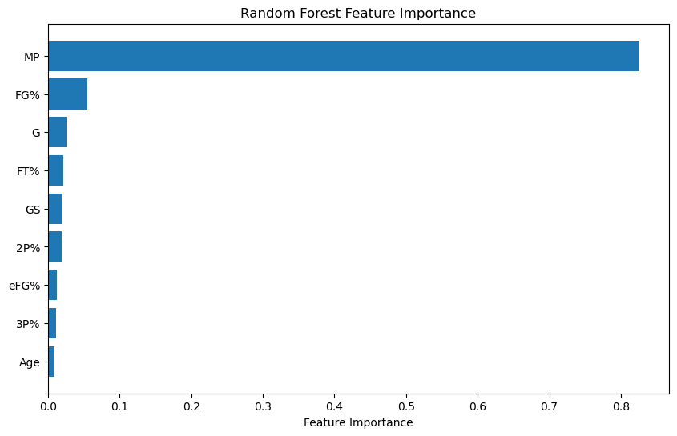

```python
X_train, X_test, y_train, y_test = train_test_split(X, y, test_size=0.1, random_state=1)

model_randomforest = RandomForestRegressor(random_state=1)

model_randomforest.fit(X_train, y_train)

y_pred = model_randomforest.predict(X_test)

mse = mean_squared_error(y_test, y_pred)
print("Mean Squared Error (MSE) for Random Forest:", mse)

feature_importance = model_randomforest.feature_importances_
sorted_idx = np.argsort(feature_importance)

plt.figure(figsize=(10, 6))
plt.barh(range(len(sorted_idx)), feature_importance[sorted_idx], align='center')
plt.yticks(range(len(sorted_idx)), np.array(X.columns)[sorted_idx])
plt.xlabel('Feature Importance')
plt.title('Random Forest Feature Importance')
plt.show()
```

## Part 5: Interpretation - Insight and Policy Decision

The purpose of this analysis was to test the hypothesis regarding the relationship between minutes played, games played, and fantasy point scoring in fantasy basketball. We posited that volume metrics, such as minutes and games played, are significant factors in determining fantasy points scored by a player.

Key Findings: Regression Analysis: The results from the least squares regression provided insights into the significance of various predictors on fantasy points.

Implications: For fantasy basketball managers, this analysis highlights the importance of considering players' minutes and games played when making roster decisions. Players who consistently play more minutes and participate in more games are likely to be more valuable in terms of fantasy points, making them strategic picks for a successful fantasy basketball season.

### References

https://www.basketball-reference.com/  
https://www.basketball-reference.com/leagues/NBA_2024_totals.html https://www.espn.com/fantasy/basketball/story/_/id/30296896/espn-fantasy-default-points-league-scoring-explained https://www.espn.com/fantasy/basketball/story/_/id/20800285/adjusting-settings https://sportsanalytics.studentorg.berkeley.edu/articles/point-centers.html